# Simple Linear Regression

Sick of stats? Get in line!

P. Lombardo

## Loading packages, etc.

```r
library(tidyverse)
library(patchwork)
library(DescTools)
library(broom)
skincancer<-read.csv('data/StateSkinCancer.csv',header = T,
                     stringsAsFactors = T)
```

## Skincancer Revisited

Consider a linear regression for the `skincancer` data set, where we regress skin cancer mortality per capita (`mortality`) onto the latitude of the state (`latitude`).

Let’s visualize this with a regression line!

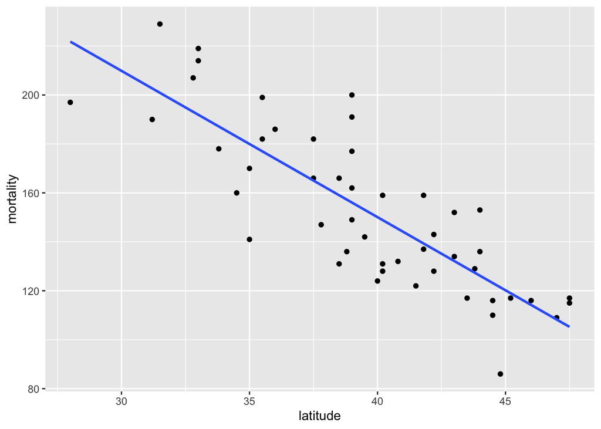

```r
# Place code here.
ggplot(data = skincancer,
       aes(x = latitude, y = mortality))+
    geom_point()+
    geom_smooth(method = "lm", formula = "y~x",
                se = F)
```

Now let’s “fit” the model and grab the coefficients:

```r
# Place code here.
cancer.model <- lm(mortality ~ latitude, data = skincancer)

coef(cancer.model)
```

```
## (Intercept)    latitude
##  389.189351   -5.977636
```

```r
confint(cancer.model)
```

```
##                  2.5 %     97.5 %
## (Intercept) 341.285151 437.093552
## latitude     -7.181404  -4.773867
```

### Information from the model:

Suppose we have more specific information on the latitude in the town where we live: 42.6 (Gloucester, MA). What does our model predict will be the skin cancer mortality per capita here?

AVG(mortality) = 390 - 6*latitude

```r
# Place code here.
390 - 6*42.6
```

```
## [1] 134.4
```

```r
cancer.model %>% augment(
    newdata = data.frame(latitude = 42.6)
) %>% select(.fitted)
```

| .fitted |
| --- |
| 134.5421 |

```r
coef(cancer.model)[1]+42.6*coef(cancer.model)[2]
```

```
## (Intercept)
##    134.5421
```

**Answer**: It estimates an average skincancer mortality of 134.4 per capita, for areas with this latitude of 42.6.

Suppose we are Gloucester, MA (Latitude 42.6) to Durham, NC (Latitude 35.99).

- Based on our regression model and this difference in latitude, what kind of difference in skin cancer mortality, on average, should we expect between these locations?

```r
# Place code here.
# change in X =
dx <- 42.6 - 35.99
# Change in y = slope * dx
coef(cancer.model)[2]*dx
```

```
##  latitude
## -39.51217
```

**Answer:** A move from Durham NC to Gloucester MA would be associated with a 39.5 per capita **drop** in skin cancer mortality.

```r
coef(cancer.model)[2]
```

```
##  latitude
## -5.977636
```

**Marginal Change Language:** *For each 1 degree increase in latitude, we would expect a 6 person per capita decrease in skin cancer mortality.*

### Inference in regression:

```r
summary(cancer.model)
```

```
##
## Call:
## lm(formula = mortality ~ latitude, data = skincancer)
##
## Residuals:
##     Min      1Q  Median      3Q     Max
## -38.972 -13.185   0.972  12.006  43.938
##
## Coefficients:
##             Estimate Std. Error t value Pr(>|t|)
## (Intercept) 389.1894    23.8123   16.34  < 2e-16 ***
## latitude     -5.9776     0.5984   -9.99 3.31e-13 ***
## ---
## Signif. codes:  0 '***' 0.001 '**' 0.01 '*' 0.05 '.' 0.1 ' ' 1
##
## Residual standard error: 19.12 on 47 degrees of freedom
## Multiple R-squared:  0.6798, Adjusted R-squared:  0.673
## F-statistic:  99.8 on 1 and 47 DF,  p-value: 3.309e-13
```

When we run a regression, what hypothesis tests do we run? There are three, but one of them is a repeat for simple linear regression. We focus on…

1. Slope: $H_0$: the slope term is equal to zero. (Mathematically, we can show this is equivalent to a two-tailed test of $\rho = 0$.)

Look at the entry for `p.value` in the second row of…

```r
cancer.model %>% tidy()
```

| term | estimate | std.error | statistic | p.value |
| --- | --- | --- | --- | --- |
| (Intercept) | 389.189351 | 23.8123158 | 16.344036 | 5.123157e-21 |
| latitude | -5.977636 | 0.5983717 | -9.989836 | 3.309456e-13 |

2. Intercept: $H_0$: the intercept coefficient is equal to zero.

Look at the entry for `p.value` in the first row of…

```r
cancer.model %>% tidy() %>%
    select(term, estimate, p.value)
```

| term | estimate | p.value |
| --- | --- | --- |
| (Intercept) | 389.189351 | 5.123157e-21 |
| latitude | -5.977636 | 3.309456e-13 |

**Exercise.** Do we have evidence, from this sample, to suggest that the slope coefficient is not equal to zero?

Yes! The individual test for slope had a small $P$-value, giving evidence the slope coefficient at the population level is not zero.

*Note*: The individual test for the intercept coefficient had a small $P$-value as well, giving evidence the intercept coefficient at the population level is not zero. This means we have evidence that when latitude is zero (i.e. the equator), the skincancer mortality is not zero. Duh.

- This points toward the fact that the inference for the intercept term is not always useful.

For simple linear regression, we primarily only care about the hypothesis test for the slope coefficient.

**Note**: The slope test is special because this tells us, along with verifying whether the population slope term is zero, whether we have a correlation as well! (Two-tailed, though….)

### How well does the linear model “fit” the data?

Loosely speaking, can we quantify “how close the dots are to the regression line”?

##### Let’s explore $R^2$!

**A useful interpretation of $R^2$**: This is the percentage of variation in your response variable that can be explained by a linear association to the explanatory variable.

Comparing $R^2$ with our new interpretation:

```r
#Place code here
# Find  1- variance of residuals / variance of mortality
1- var(cancer.model$residuals)/var(skincancer$mortality)
```

```
## [1] 0.6798296
```

```r
# compare againstresiduals# compare against our R^2 value.
cancer.model %>% glance() %>% select(r.squared) %>% unlist()
```

```
## r.squared
## 0.6798296
```

**Answer**: We have an R-squared value of 0.68. We can interpret this as meaning roughly 68% of the variation we see in skincancer mortality can be explained (not causally) by its correlation with the latitude variable.

- Generally speaking, R-squared values close to 1 are best, with 1 indicating all the variation has been explained away by the explanatory variable (or the dots lie exactly on the trendline).

#### Residual standard error:

On average, how far (as measured in the $y$-direction) is a typical dot from the prediction made by our regression line?

We estimate this error using the residual standard error (RSE):

```r
# Residual Standard Error
cancer.model %>% glance() %>% select(sigma)
```

| sigma |
| --- |
| 19.11503 |

The residual standard error is, loosely speaking, about the same as the standard deviation of the residuals (distances of the data points form the line.)

```r
cancer.model$residuals %>% sd()
```

```
## [1] 18.91487
```

So, how useful is this predictive line?

One average, an individual state’s skin-cancer mortality rate is about 19.1 units (ppl per capita) from the regression line prediction.

- Generally speaking, RSE values closer to zero indicate a stronger fit, with a value of zero indicating all the data falls exactly on the trendline.

## Do we have modeling assumptions here?

Yes… do we have time?

## Bonus!

Is there a notion of a confidence interval *for the line* based on the sampling variation we see in the intercept and slope?

Yes! Bare with me code-wise…

```r
#create population
test_x<-rnorm(5000, 60, 15)
test_y<-1.3*test_x + rnorm(5000,0,15)

#Gather population model
pop_model<-lm(test_y~test_x)
N<-length(test_x)

#grab a sample model
samp_ind_1<-sample(1:N,30)
samp_data<-data.frame(xs = test_x[samp_ind_1],
                      ys = test_y[samp_ind_1])
sample_model<-lm(ys~xs, data = samp_data)
cfs<-coef(sample_model)

# hlepful function
get_hat_beta<-function(){
    samp_ind<-sample(1:N,30)
    samp_model<-lm(test_y[samp_ind]~test_x[samp_ind])
    return(coef(samp_model))
}

# loop through to get about coefficieents for
# about 250 regressions run from random samples.
samp_betas<-matrix(numeric(3*250),ncol=3)
for(j in 1:250){
  samp_betas[j,]<-c(get_hat_beta(),paste("sample",j,sep=""))
}
# make it a data frame and clean it up.
samp_betas<-as.data.frame(samp_betas)
names(samp_betas)<-c("beta0","beta1","sampleNum")
samp_betas$beta0<-as.numeric(samp_betas$beta0)
samp_betas$beta1<-as.numeric(samp_betas$beta1)
```

Let’s start with the population level model (i.e. the truth!):

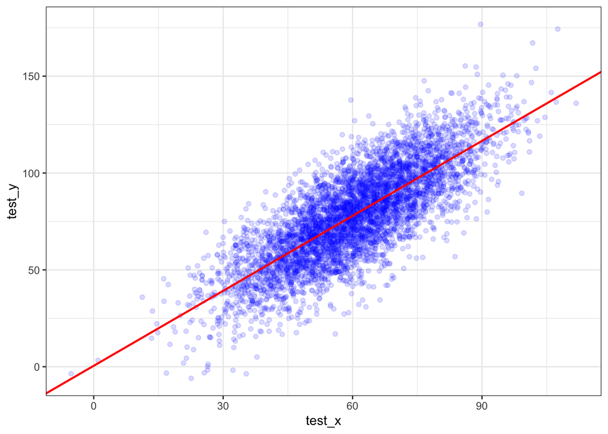

```r
G1<-ggplot()+
  geom_point(aes(x=test_x, y=test_y),
             color='blue',alpha=.15)+theme_bw()+
    geom_abline(intercept = coef(pop_model)[1],
                slope = coef(pop_model)[2],
                color='red',
                linewidth =.8)

G1
```

Now let’s add in the 250 simulated regression fits:

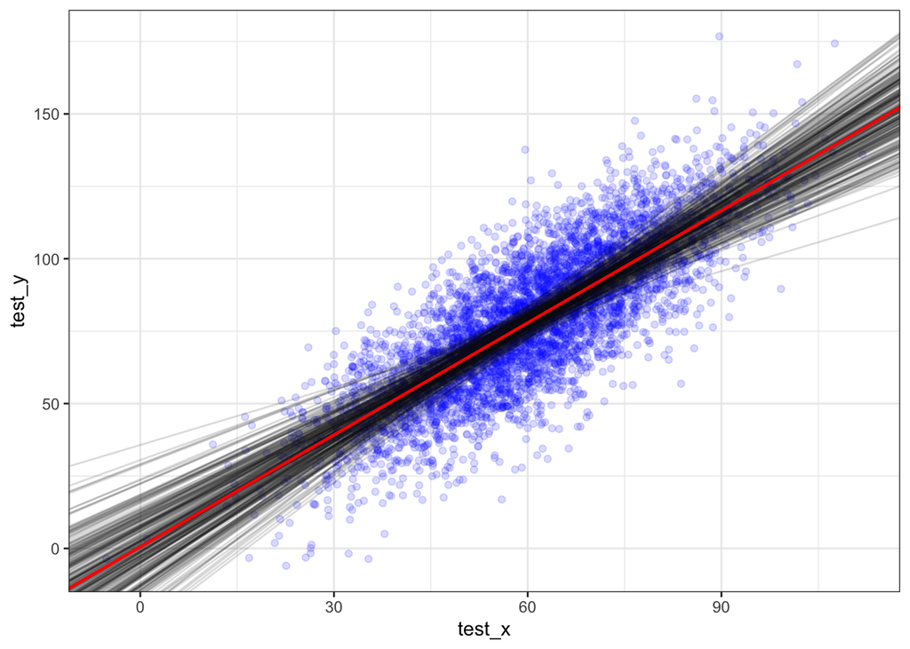

```r
for (i in 1:250){
    G1<-G1+geom_abline(intercept = samp_betas[i,1],
                       slope = samp_betas[i,2],
                       color='gray1',
                       alpha = .15)
}

G1 + geom_abline(intercept = coef(pop_model)[1],
                slope = coef(pop_model)[2],
                color='red',
                linewidth =.8)
```

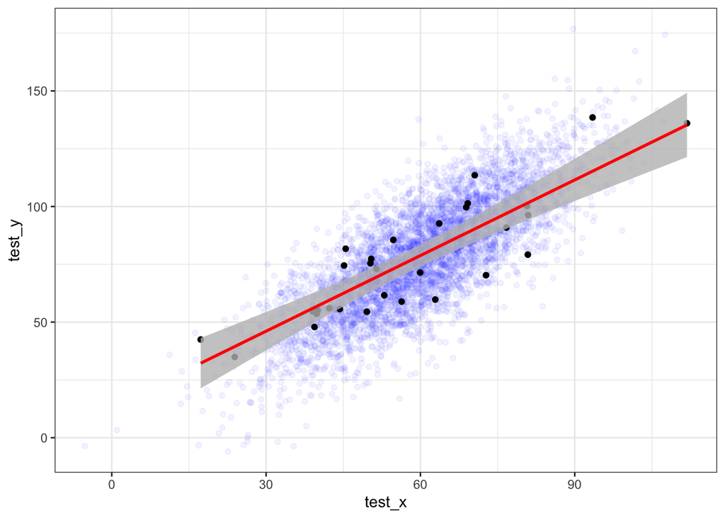

```r
ggplot()+
        geom_point(aes(x= test_x,
                   y = test_y),
                   color='blue',
                   alpha = .05)+
    geom_point(data = samp_data,
       aes(x = xs, y = ys))+
    geom_smooth(data = samp_data,
       aes(x = xs, y = ys),
       method = "lm",
                formula = y~x,color='red',
       fill = 'gray',alpha = .8)+
    theme_bw()
```